# R俱乐部

## day02

### 杜 月新

### RStudio

### 2020/10/19

##Day02 图表的介绍与概率分布

# R里基本的图表

1.散布图 （scatter plot）

2.折线图 （line graph）

3.柱形图  (bar graph)

4.箱型图  （box plot）

- 图形参数

http://cse.naro.affrc.go.jp/takezawa/r-tips/r/53.html

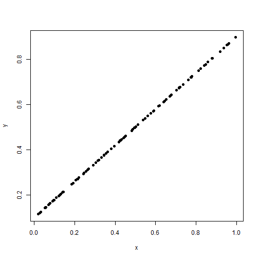

```r
# 散布图
x = runif(100)     #随机生成100个乱数
y = 0.8 * x + 0.1
plot(x, y, pch=16)
```

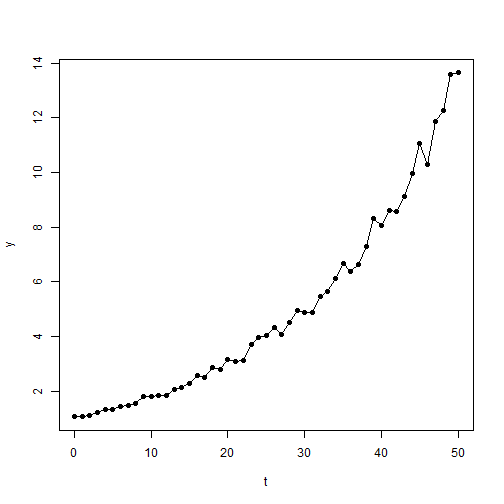

```r
# 折线图
t = 0:50
shocks = 0.2 * runif(length(t))
y = exp(0.05 * t) * (1 + shocks)
plot(t, y, type="l")
points(t, y, type="p", pch=16)
```

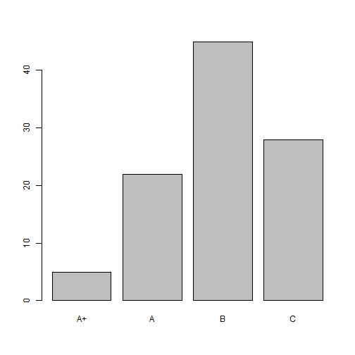

```r
# 柱形图
grades = c("A+", "A", "B", "C")
grades = ordered(grades, levels = grades)  #ordered：按序排列
prob = c(0.05, 0.20, 0.5, 0.25)
students = sample(grades, 100, replace = TRUE, prob = prob)
barplot(table(students))
```

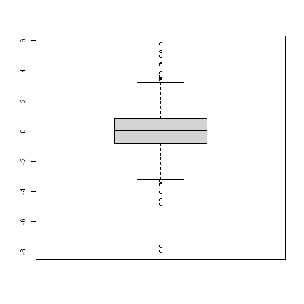

```r
# 箱型图
x = rt(500, df = 3)    #自由度为3的t分布
boxplot(x)
```

# 从箱型图看分布的一些概要

**统计小知识**

- 数据的中心

「样本平均」:

`$$\bar{X}=\frac{1}{n}\sum_{i=1}^nX_i$$`

>R： mean（x）

>注:
- 如果偏值（outlier）比较多的情况下，也会经常用截尾平均值（trimmed mean）→mean(x,trim=0.5)
或者中央值(median)→median（）来表示样本数据的中心。

>
- 如果外侧所占的比例逐渐减小，这时候也可以采用加权平均来计算。

```r
x = c(100, 200, 300)
weight = c(0.3, 0.3, 0.4)
weighted.mean(x, weight)
```

```
## [1] 210
```

- 加权平均数

`$$\bar{x}=\frac{x_{1}w_{1}+x_{2}w_{2}+...+x_{n}w_{n}}{w_{1}+w_{2}+...+w_{n}}$$`

## 画图尝试一下

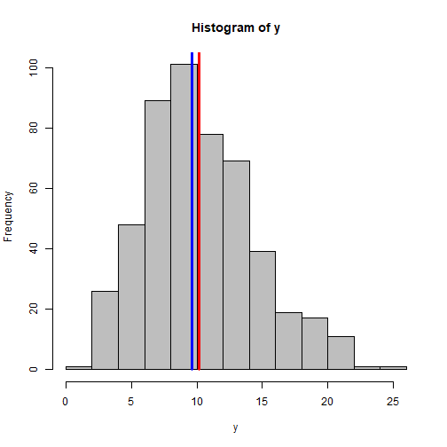

```r
y = rchisq(500, 10)  # 自由度10的卡方分布
hist(y, col = "gray")
segments(mean(y), 0, mean(y), 300, lw = 3, col = "red")
segments(median(y), 0, median(y), 300, lw = 3, col = "blue")
```

# 尺度

例如：柱形图横向发展多少？

⇒这个值即被称为尺度。统计学中代表性的指标有标准差或方差。

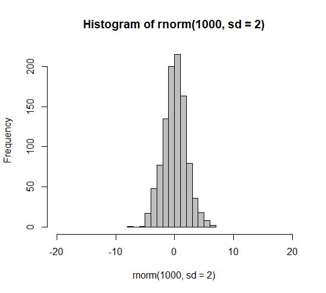

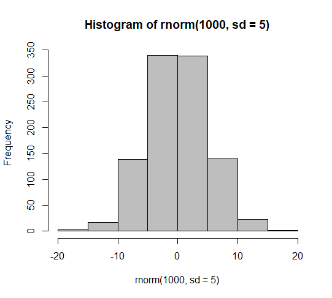

```r
hist(rnorm(1000, sd = 2), col = "gray", xlim = c(-20, 20))
hist(rnorm(1000, sd = 5), col = "gray")
```

** 尺度的指标①：方差 （Variance）**

`$$s^{2}=\frac{1}{n-1}\sum_{i=1}^n(X_i-\bar{X})^{2}$$`
- 最被经常使用的尺度标准。R里用var（）来表示。同时也被称为样本方差。

>注意：样本方差的另一种计算方法↓
`$$样本方差=\frac{1}{n}\sum_{i=1}^n(X_i-\bar{X})^{2}$$`
这种计算方法还有在使用中。

** 尺度的指标②:标准差（均方差）（Standard Deviation）**

方差值为2次方的值，此时，元数据与单位不符合。↓

取方差的平方根即为标准差。

```r
x = rnorm(1000, sd = 10)   # sd 标准差！
var(x)
```

```
## [1] 100.1939
```

```r
sd(x)
```

```
## [1] 10.00969
```

```r
sd(x) - sqrt(var(x))
```

```
## [1] 0
```

** 尺度的指标③:四分位距（四分差）（interquartile range, IQR）**

- 第一四分位数(Q1)，又称“较小四分位数”，等于该样本中所有数值由小到大排列后第25%的数字。

- 第二四分位数(Q2)，又称“中位数”，等于该样本中所有数值由小到大排列后第50%的数字。

- 第三四分位数(Q3)，又称“较大四分位数”，等于该样本中所有数值由小到大排列后第75%的数字。

**第三四分位数与第一四分位数的差距又称四分位距（InterQuartile Range, IQR）。**

>如果是正态分布的情况下，IQR/1.349即标准偏差的无偏估计(unbiased estimator)。

```r
IQR(x) / 1.349
```

```
## [1] 9.617932
```

```r
qnorm(0.75) - qnorm(0.25)
```

```
## [1] 1.34898
```

**尺度的指标④：最大值与最小值**

R：

- max()

- min()

- range()

** 尺度的指标⑤: 绝对中位差（Median absolute deviation）**

- 用途：绝对中位差是一种统计离差的测量,比标准差更能适应数据集中的异常值。对于标准差，使用的是数据到均值的距离平方，所以大的偏差权重更大，异常值对结果也会产生重要影响。对于MAD，少量的异常值不会影响最终的结果。

>中央值作为尺度指标时→绝对中位差

`$$MAD=Median({|X_i-Median(X)|}$$`
i=1,2,3....n

>R语言中返回的是估计的标准差   `$$MADN=1.4826×MAD$$`
→正规分布的时候，被称为标准差的无偏估计(unbiased estimator)。

# MADN

R语言中，MADN用函数MAD（）来计算。

```r
sd(x)
```

```
## [1] 10.00969
```

```r
mad(x)
```

```
## [1] 9.629287
```

# 概率分布

R中与xxx分布有关的函数包括：
- dxxx(x)，即xxx分布的分布密度函数(PDF)或概率函数(PMF)。

- pxxx(q)， 即xxx分布的分布函数(CDF)。

- qxxx(p)， 即xxx分布的分位数函数q(p)。

- rxxx(n)， 即xxx的随机数函数，可以生成n个xxx的随机数。

*上节课的回忆*

-[0,1)上的均匀分布：平均值为1/2，分散值为1/12

-runif（n):在均匀分布上，生成一系列乱数

* mean（n）：计算标本平均

```r
 n=1000
 z=(mean(runif(n)) - 0.5) / sqrt((1/12) / n)
 z
```

```
 ## [1] 0.6781885
```

# 标准化与中心极限定理

- 假设我们现在从同一分布（平均值为μ，方差为σ2）中独立抽出
`$$X_i,i=1,2....n$$`
此时，标本平均$$\bar{X}=\frac{1}{n}\sum_{i=1}^{X_i}$$
**在这组标本数据里，平均值=μ，方差=σ2/n。**

- 而当n越来越大，从标本平均里减去平均值，再除以标准差，即
`$$Z=\frac{\bar{X}-\mu}{\sqrt{\sigma^2/n}}$$`
近似地服从标准正态分布N(0，1）。
> t分布  （平均值为0，但是方差不确定（σ2））

# 问题

1. X在平均值为0，标准差为1的正态分布上，X分布在-0.5到0.5之间的概率有多少？ （hint：pnorm）

2. X在平均值为0，标准差为5的正规分布上，2.5%概率的X值和（1-2.5%）概率的X值分别为多少？ （hint：qnorm）

1.

```r
pnorm(0.5)-pnorm(-0.5)
```

```
## [1] 0.3829249
```

2.

```r
qnorm(0.025,sd=5)
```

```
## [1] -9.79982
```

```r
qnorm(1-0.025,sd=5)
```

```
## [1] 9.79982
```

# 检定的一些想法

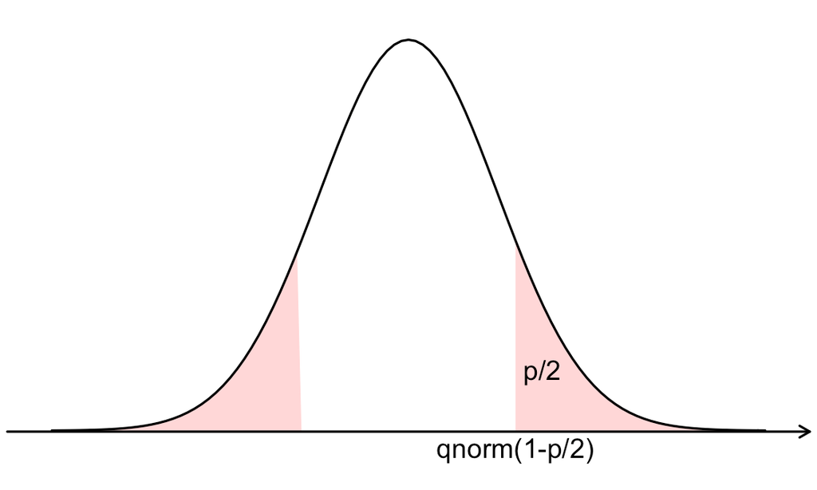

- 以特定的假说（例如：归无假说）为基础，正态分布的情况下，图中粉色部分的内容

→是否是出现的概率太低？

→假定是否错误？

** Next 。。。**

# 练习

- data: sample.xlsx
- 1.画出北京房价与M2supply的散布图或者折线图？

- 2.分别求出北京房价与M2supply的平均数，中央值，最大最小值以及标准差？

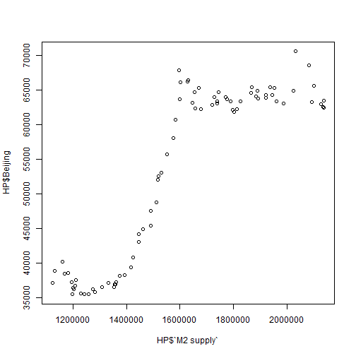

```r
library(readxl)
HP=read_excel("sample.xlsx")
plot(HP$`M2 supply`,HP$Beijing,type="p")
```

```r
summary(HP$Beijing)
```

```
##    Min. 1st Qu.  Median    Mean 3rd Qu.    Max.
##   35494   38537   62252   53600   63993   70627
```

```r
sd(HP$Beijing)
```

```
## [1] 12497.39
```

```r
summary(HP$`M2 supply`)
```

```
##    Min. 1st Qu.  Median    Mean 3rd Qu.    Max.
## 1123521 1359800 1601360 1611701 1865900 2136837
```

```r
sd(HP$`M2 supply`)
```

```
## [1] 296737.6
```